# Exercise II

```r
knitr::opts_chunk$set(
    fig.width = 6,
    fig.asp   = 1,
    fig.align = "center",
    message   = FALSE,
    warning   = FALSE
)
```

```r
library(tidyverse)
library(broom)      # for extracting tidy data frames from statsitical objects
library(car)        # general functions related to linear models, in particular Anova function
library(heplots)    # for eta-square calculations, i.e. etasq function
library(emmeans)    # for pairwise contrasts
library(gt)         # for making nice tables
library(effsize)    # for Cohen's d and Glass' delta
library(sandwich)   # For heteroscedasticity-consistence variance-covariance estimatros
library(lmtest)     # For regression coefficients tests with custom variance-covariance matrices, i.e. coeftest function
library(simpleboot) # For easy bootstraping of regression models
library(rstatix)
library(ggpubr)
library(ggplot2)
library(lmtest)
library(BioStatR)
library("GGally")
library(rcompanion)
library(ggiraphExtra)
library(lavaan)
library(mediation)

## GGplot settings
theme_set(theme_bw())
```

# Pen-and-paper problems

## 1.

Let $X_1$, $X_2$ and $X_3$ be three random variables with means $\mu_1$, $\mu_2$ and $\mu_3$, variances $\sigma^2_1$, $\sigma^2_2$ and $\sigma^2_3$ and covariances $\sigma_{ij}$ for $i, j = 1, 2, 3$ (for instance, $\sigma_{12} = \text{Cov}[X_1, X_2]$ and $\sigma_{11} = \sigma^2_1 = \text{Var}[X_1]$).

Consider a random vector $\mathbf{x} = (X_1, X_2, X_3)$. Answer the following questions:

- What is the expected value of $\mathbf{x}$, that is, $\mathbb{E}[\mathbf{x}]$? Answer: $\mathbf{x}$ is a random vector and the expected value of a random vector is a vector of expected values of its elements.

$$\mathbb{E}[x] = (\mathbb{E}[X_1], \mathbb{E}[X_2], \mathbb{E}[X_3]) = (\mu_1, \mu_2, \mu_3)$$

- What is variance of $\mathbf{x}$, that is, $\text{Var}[\mathbf{x}]$?

Answer:

The variance of a vector is a matrix:

$$\text{Var}[\mathbf{x}] =
\begin{pmatrix}
\text{Var}[\mathbf{X_1}] & \text{Cov}[\mathbf{X_1, X_2}] & \text{Cov}[\mathbf{X_1, X_3}]\\
\text{Cov}[\mathbf{X_2, X_1}] & \text{Var}[\mathbf{X_2}] & \text{Cov}[\mathbf{X_2, X_3}]\\
\text{Cov}[\mathbf{X_3, X_1}] & \text{Cov}[\mathbf{X_3, X_2}] & \text{Var}[\mathbf{X_3}]
\end{pmatrix}$$
$$\text{Var}[\mathbf{x}] =
\begin{pmatrix}
\sigma^2_1 & \sigma_{12} & \sigma_{13}\\
\sigma_{21} & \sigma^2_2 & \sigma_{23}\\
\sigma_{31} & \sigma_{32} & \sigma^2_3
\end{pmatrix}$$

- What is variance of $\mathbf{x}$ assuming that all covariances $\sigma_{ij}$ for $i \neq j$ are zero? What kind of an assumption commonly used in statistical models does such a variance-covariance matrix represents?

Answer:

The variance is a following matrix:

$$\text{Var}[\mathbf{x}] =
\begin{pmatrix}
\sigma^2_1 & 0 & 0\\
0 & \sigma^2_2 & 0\\
0 & 0 & \sigma^2_3
\end{pmatrix}$$
This variance-covariance matrix represents that $\mathbf{x} = (X_1, X_2, X_3)$ consists of elements that are independent

- What is variance of $\mathbf{x}$ assuming that all covariances $\sigma_{ij}$ are zero and all variances $\sigma^2_{i}$ for $i = 1, 2, 3$ are equal to a specific number $\sigma^2$? What kinds of important assumptions (commonly used in linear models) does such a variance-covariance matrix represent? How can you write this matrix in the most concise way possible?

Answer:

If all variances are equal to $\sigma^2$, then $\text{Var}[\mathbf{x}]$ is equal to:

$$\text{Var}[\mathbf{x}] =
\begin{pmatrix}
\sigma^2 & 0 & 0\\
0 & \sigma^2 & 0\\
0 & 0 & \sigma^2
\end{pmatrix}
=
\sigma^2
\begin{pmatrix}
1 & 0 & 0\\
0 & 1 & 0\\
0 & 0 & 1
\end{pmatrix}
=
\sigma^2\textbf{I}_{3x3}$$
, where $\textbf{I}_{3x3}$ is a 3x3 identity matrix. The assuption is that this variance-covariance matrix represents that $\mathbf{x} = (X_1, X_2, X_3)$ consists of elements that are independent and identically distributed

## 2.

Let:

$$\mathbf{X} =
\begin{pmatrix}
1 & 2 \\
0 & 3 \\
1 & 1
\end{pmatrix}
\qquad
\mathbf{y} =
\begin{pmatrix}
1 \\ 2
\end{pmatrix}$$
Answer the following questions:

- What is $\mathbf{Xy}$?

Answer: It is a linear transformation of a vector y with X:

$$\mathbf{Xy} =
\begin{pmatrix}
1*1 + 2*2 \\
0*1 + 3*2 \\
1*1 + 1*2
\end{pmatrix} =
\begin{pmatrix}
5 \\
6 \\
3
\end{pmatrix}$$

- What are the dimensions (shape) of $\mathbf{X}$?

$\mathbf{X}$ has 3 rows and 2 columns, so it has a shape of 3x2

- $\mathbf{X}$ is a matrix so it is a (linear) function from $\mathbb{R}^p$ to $\mathbb{R}^q$. What are the values of $p$ and $q$?

Answer: $f:\mathbb{R}^p \rightarrow \mathbb{R}^q$ $\\p=2$ $\\q=3$

Linear transformation $f$ results in a 3x2 matrix $\mathbf{X}$

- Consider the transpose $\mathbf{X}^\top$. Write it down. It is still a matrix so it is a (linear) function from $\mathbb{R}^r$ to $\mathbb{R}^s$. What are the values of $r$ and $s$?

Answer:

$$\mathbf{X}^\top =
\begin{pmatrix}
1 & 0 & 1 \\
2 & 3 & 1
\end{pmatrix}$$
$f:\mathbb{R}^r \rightarrow \mathbb{R}^s$ $r=3$ $s=2$

- Is $\mathbf{X}$ of **full column rank** (no column can be expressed as a linear combination of other columns)? What if $\mathbf{X}$ was:

$$\mathbf{X} =
\begin{pmatrix}
1 & 2 & 2 \\
0 & 3 & 0 \\
1 & 1 & 2
\end{pmatrix}$$

Answer: To check if $\mathbf{X}$ is of full column rank, we have to check if $\mathbf{X}^\top\mathbf{X}$ is invertible

$$\mathbf{X}^\top\mathbf{X} = \begin{pmatrix}
2 & 3 \\
3 & 14
\end{pmatrix}$$

This matrix is square, so we can move on further to check if it is invertible. To do so, it must meet the following requirement. Let’s call $\mathbf{X}^\top\mathbf{X}$ as $A$ then: $\mathbf{A}^{-1}\mathbf{A} = \mathbf{A}\mathbf{A}^{-1} = \textbf{I}_{nxn}$ Let’s check:

$$\mathbf{A}^{-1} =
\begin{pmatrix}
\frac {14}{19} & \frac {-3}{19} \\
\frac {-3}{19} & \frac {2}{19}
\end{pmatrix}
\\\mathbf{A}^{-1}\mathbf{A} = \begin{pmatrix}
\frac {14}{19} & \frac {-3}{19} \\
\frac {-3}{19} & \frac {2}{19}
\end{pmatrix}
\begin{pmatrix}
2 & 3 \\
3 & 14
\end{pmatrix} =
\begin{pmatrix}
1 & 0 \\
0 & 1
\end{pmatrix}
\\\\\mathbf{A}\mathbf{A}^{-1} =
\begin{pmatrix}
2 & 3 \\
3 & 14
\end{pmatrix}
\begin{pmatrix}
\frac {14}{19} & \frac {-3}{19} \\
\frac {-3}{19} & \frac {2}{19}
\end{pmatrix}
=
\begin{pmatrix}
1 & 0 \\
0 & 1
\end{pmatrix}
\\\begin{pmatrix}
1 & 0 \\
0 & 1
\end{pmatrix} = \textbf{I}_{2x2}$$
It holds, so $\mathbf{X}$ is of **full column rank**

For

$$\mathbf{X} =
\begin{pmatrix}
1 & 2 & 2 \\
0 & 3 & 0 \\
1 & 1 & 2
\end{pmatrix}$$

$$\mathbf{X}^\top\mathbf{X} = \begin{pmatrix}
1 & 0 & 1 \\
2 & 3 & 1 \\
2 & 0 & 2
\end{pmatrix}
\begin{pmatrix}
1 & 2 & 2 \\
0 & 3 & 0 \\
1 & 1 & 2
\end{pmatrix} =
\begin{pmatrix}
2 & 3 & 4 \\
3 & 14 & 6 \\
4 & 6 & 8
\end{pmatrix} = A$$
$\text det \textbf{A} = 0$, therefore $A$ is not invertible (so $X$ is not of **full column rank** )

## 3.

- What is the meaning of $R^2$? What is the difference between $R^2$ and $\eta^2$. When are they equal?

Answer: $R^2$ is a determination coefficient and this is a measure that takes value between 0 and 1. It informs to what point differences in one variable can be explained by a difference in another variables overall in the model (percentage of the variable’s variation that is explained by the other variable). This value measures the strength of a linearity between two variables (the higher value of $R^2$, the better linearity). $\eta^2$ is informing us how much variance of dependent variable is explained by the independent variable, but it is different than $R^2$ in that the $\eta^2$ studies importance of a single model variable. For one-way ANOVA, $R^2$ and $\eta^2$ will be equal, because there is only one independent variable.

- What is the relationship between $\eta^2$ (and total sum of squares in general) and balanced designs?

Answer: For balanced designs, when all groups are equal, the total sum of squares is spread equally on all factors and $\eta^2$ values for all variables together are equal to $R^2$. For unbalanced groups, however, variation explained by variables can intersect which results in a ridiculous value of $\eta^2$ higher than 1.

- What is partial $\eta^2$ and why it can be a better measure of effect size for highly unbalanced designs?

## 4.

Let $\mathbf{x} = (\text{blue, blue, green, green, brown, brown})$ be a vector of categorical measurements of eye colors of six persons.

- Write down the design matrix $\mathbf{X}$ representing a one-way ANOVA design using treatment (dummy) coding (including the intercept column).

Answer:

$$\mathbf{X} = \begin{pmatrix}
1 & 0 & 0 \\
1 & 1 & 0 \\
1 & 0 & 1
\end{pmatrix}$$
* How many regression coefficients are in this model including $b_0$ (the intercept)?

Answer: There are 3 regression coefficients:

$$\beta = \begin{pmatrix}
\beta_0 \\
\beta_1 \\
\beta_2
\end{pmatrix}$$

- What are the interpretations of the regression coefficients?

Answer:

$\beta_0$, intercept coefficient, denotes mean in the first group (blue). $\beta_1$ and $\beta_2$ are slope coefficients that can be interpreted as:

$\beta_1$ difference between mean in the first group (blue) and mean in the second group (green).

$\beta_2$ is the difference between mean in the first group (blue) and mean in the third group (brown).

- Write down equations for sample means in groups in terms of regression coefficients.

$$\mu_1 = \beta_0
\\\mu_2 = \beta_0 + \beta_1
\\\mu_3 = \beta_0 + \beta_2$$

## 5.

In this exercise we will derive a coding scheme for one-way ANOVA with $3$ groups known as *effect coding* or *sum to zero contrasts*. An effect coding scheme should meet the following requirements:

1. Intercept is equal to the arithmetic average of group means.
2. The first regression coefficient $b_1$ should be equal to the difference between the mean in the first group and the arithmetic average of all group means.
3. The second regression coefficient $b_2$ should be equal to the difference between the mean in the second group and the arithmetic average of all group means.

Start by creating a hypothesis matrix representing the above contraints in rows (one row should be a contrasts vector for one contraint) and then convert it (by inverting) to a contrast matrix (a design matrix that represents a one-way ANOVA with given coding scheme). A correct contrasts matrix should have only $1$’s in the first column (the intercept column).

Effect coding makes most sense for balanced designs (or when group sizes are not meaningful). Why?

Answer:

Row 1: $\mu_{all} = \frac{(\mu_1+\mu_2+\mu_3)}{3} = \color {red} {\frac {1} {3}} \mu_1 + \color {red} {\frac {1} {3}} \mu_2 + \color {red} {\frac {1} {3}} \mu_3$

Row 2: $\mu_1 - \mu_{all} = \mu_1 - \frac {1} {3} \mu_1 - \frac {1} {3} \mu_2 - \frac {1} {3} \mu_3 = \color {red} {\frac {2} {3}} \mu_1 \color {red} {- \frac {1} {3}} \mu_2 \color {red} {- \frac {1} {3}} \mu_3$

Row 3: $\mu_2 - \mu_{all} = \mu_2 - \frac {1} {3} \mu_1 - \frac {1} {3} \mu_2 - \frac {1} {3} \mu_3 = \color {red} {- \frac {1} {3}} \mu_1 + \color {red} {\frac {2} {3}} \mu_2 \color {red} {- \frac {1} {3}} \mu_3$

Hypothesis matrix $\textbf {W}$:

$$\textbf {W} = \begin{pmatrix}
\frac {1}{3} & \frac {1}{3} & \frac {1}{3} \\
\frac {2}{3} & -\frac {1}{3} & -\frac {1}{3} \\
-\frac {1}{3} & \frac {2}{3} & -\frac {1}{3}
\end{pmatrix}$$

Contrast matrix can be created by inverting hypothesis matrix $\textbf {W}$

$$\textbf {W}^{-1} = \begin{pmatrix}
1 & 1 & 0 \\
1 & 0 & 1 \\
1 & -1 & -1
\end{pmatrix}$$

Effect coding makes most sense for balanced designs (or when group sizes are not meaningful). Why?

Answer: Balanced design means that the sizes of all groups are equal. Why group sizes matter in effect coding? Because measures that use group sizes may then give false results. For example, in calculating the mean of all observations, the grand mean for unequal groups will be different than the mean of all means. In the $\textbf {W}$ matrix above arithmetic average and grand mean are equal for balanced design, but if group sizes weren’t equal and we wanted to calculate grand mean, it wouldn’t be the right way.

# Coding problems

## 1.

In this problem you will work with `Guyer` dataset (from `carData` package) which we already know from the notebook 9 (`9-linear-model-3`). We will use it to examine an important issue related to different kinds of test for linear models and some complications with standard summaries generated by `R`.

```r
data("Guyer")
Guyer <- tibble(Guyer)
Guyer
```

```
# A tibble: 20 x 3
   cooperation condition sex
         <dbl> <fct>     <fct>
 1          49 public    male
 2          64 public    male
 3          37 public    male
 4          52 public    male
 5          68 public    male
 6          54 public    female
 7          61 public    female
 8          79 public    female
 9          64 public    female
10          29 public    female
11          27 anonymous male
12          58 anonymous male
13          52 anonymous male
14          41 anonymous male
15          30 anonymous male
16          40 anonymous female
17          39 anonymous female
18          44 anonymous female
19          34 anonymous female
20          44 anonymous female
```

- First, generate a basic summary for the two-way ANOVA model with interaction `coopeation ~ sex * condition`. What does this summary suggests, in particular with respect to significance of effects?

ANSWER: First, we fit the model allowing interactions and generate a summary.

```r
model <- lm(cooperation ~ sex * condition, data = Guyer)
summary(model)
```

```
Call:
lm(formula = cooperation ~ sex * condition, data = Guyer)

Residuals:
   Min     1Q Median     3Q    Max
-28.40  -5.30  -0.40   7.45  21.60

Coefficients:
                        Estimate Std. Error t value Pr(>|t|)
(Intercept)               40.200      5.862   6.858 3.85e-06 ***
sexmale                    1.400      8.290   0.169   0.8680
conditionpublic           17.200      8.290   2.075   0.0545 .
sexmale:conditionpublic   -4.800     11.724  -0.409   0.6877
---
Signif. codes:  0 '***' 0.001 '**' 0.01 '*' 0.05 '.' 0.1 ' ' 1

Residual standard error: 13.11 on 16 degrees of freedom
Multiple R-squared:  0.2911,    Adjusted R-squared:  0.1582
F-statistic:  2.19 on 3 and 16 DF,  p-value: 0.1289
```

From the summary we can see that there is definitely no significant main effect of sex and interaction. Main effect of condition is questionable, but rather not significant. This is what I see looking at summary, but to draw proper conclusion we need further tests.

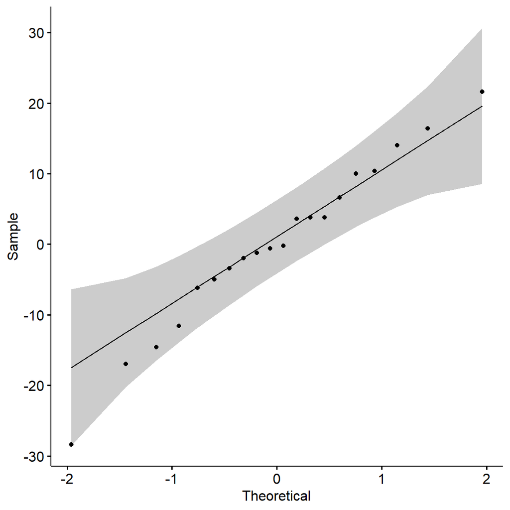

```r
ggqqplot(residuals(model))
```

- Now, generate summaries for ANOVAs with type II and type III sums of squares using either `Anova` function (from `car` package) or `etasq` function (from `heplots`) package. Do you see any important differences?

Answer:

Anova type II:

```r
etasq(model, anova = TRUE, partial = FALSE)
```

```
Anova Table (Type II tests)

Response: cooperation
                 eta^2 Sum Sq Df F value  Pr(>F)
sex           0.001289    5.0  1  0.0291 0.86669
condition     0.282399 1095.2  1  6.3739 0.02253 *
sex:condition 0.007426   28.8  1  0.1676 0.68767
Residuals              2749.2 16
---
Signif. codes:  0 '***' 0.001 '**' 0.01 '*' 0.05 '.' 0.1 ' ' 1
```

Anova type III:

```r
etasq(model, anova = TRUE, partial = FALSE, type = 3)
```

```
Anova Table (Type III tests)

Response: cooperation
                eta^2 Sum Sq Df F value    Pr(>F)
(Intercept)   2.08349 8080.2  1 47.0258 3.851e-06 ***
sex           0.00126    4.9  1  0.0285   0.86801
condition     0.19071  739.6  1  4.3044   0.05451 .
sex:condition 0.00743   28.8  1  0.1676   0.68767
Residuals             2749.2 16
---
Signif. codes:  0 '***' 0.001 '**' 0.01 '*' 0.05 '.' 0.1 ' ' 1
```

Which one seems to agree more with the summary generated by `summary` function?

Type III and summary agree more, as the results are very similar. For Type II we can see a significant effect of condition (for $\alpha = 0.05$), which is not the case for neither Type III, nor summary.

- Now, recall that type II ANOVA gives **maximally powerfull** test for main effects if there is no significant interaction (see `9-linear-model-3` notebook if you do not remember what it is about). Does this information help you to understand your results and decide which one of them is correct (type II or type III sums of squares)?

ANSWER: Yes. In our model we don’t seem to have a significant interaction effect (p = 0.68767), so we can trust Type II Anova to give us maximally powerful main effects test. Therefore, I think Type II gave us correct results.

- Estimate magnitude of the main effect of `condition` by comparing estimated marginal means in `condition = public` and `condition = anonymous` groups (averaged over levels of `sex`) and test if the difference between them is significant. You can do this easily with functions from `emmeans` package (see examples from `9-linear-model-3`). Does the result of this test agree with the result of the type II or type III ANOVA?

ANSWER:

```r
tapply(Guyer$cooperation, Guyer$condition, mean)
```

```
anonymous    public
     40.9      55.7
```

The means look quite different, but let’s conduct a proper test

```r
pairs(emmeans(model, "condition")) %>%
  confint()
```

```
 contrast           estimate   SE df lower.CL upper.CL
 anonymous - public    -14.8 5.86 16    -27.2    -2.37

Results are averaged over the levels of: sex
Confidence level used: 0.95
```

Difference between anonymous and public means is significant - 95% confidence interval = (-27.2, -2.37). This conclusion agrees only with Type II Anova summary, as there main effect of condition was also significant.

## 2.

Use `Moore` dataset from `carData` package (type in `?Moore` in the console for details).

```r
data("Moore")
Moore <- tibble(Moore)
Moore
```

```
# A tibble: 45 x 4
   partner.status conformity fcategory fscore
   <fct>               <int> <fct>      <int>
 1 low                     8 low           37
 2 low                     4 high          57
 3 low                     8 high          65
 4 low                     7 low           20
 5 low                    10 low           36
 6 low                     6 low           18
 7 low                    12 medium        51
 8 low                     4 medium        44
 9 low                    13 low           31
10 low                    12 low           36
# ... with 35 more rows
```

- First do one-way ANOVA for `conformity ~ partner.status`. ANSWER:

```r
levels(Moore$partner.status)
```

```
[1] "high" "low"
```

```r
one_mod <- lm(conformity ~ partner.status, data = Moore)
summary(one_mod)
```

```
Call:
lm(formula = conformity ~ partner.status, data = Moore)

Residuals:
    Min      1Q  Median      3Q     Max
-7.2174 -2.9545 -0.2174  2.7826 14.0455

Coefficients:
                  Estimate Std. Error t value Pr(>|t|)
(Intercept)         14.217      1.008  14.105  < 2e-16 ***
partner.statuslow   -4.263      1.442  -2.957  0.00503 **
---
Signif. codes:  0 '***' 0.001 '**' 0.01 '*' 0.05 '.' 0.1 ' ' 1

Residual standard error: 4.834 on 43 degrees of freedom
Multiple R-squared:  0.169, Adjusted R-squared:  0.1497
F-statistic: 8.744 on 1 and 43 DF,  p-value: 0.005029
```

- Then do ANCOVA with one categorical factor and one continuous covariate: `conformity ~ partner.status + fscore`. Does including the authoritarianism score change anything?

```r
one_mod_anc <- update(one_mod, ~ . + fscore)
anova(one_mod, one_mod_anc)
```

```
Analysis of Variance Table

Model 1: conformity ~ partner.status
Model 2: conformity ~ partner.status + fscore
  Res.Df    RSS Df Sum of Sq      F Pr(>F)
1     43 1004.9
2     42 1004.2  1   0.62892 0.0263 0.8719
```

```r
etasq(one_mod_anc, anova = TRUE, partial = TRUE)
```

```
Anova Table (Type II tests)

Response: conformity
               Partial eta^2  Sum Sq Df F value   Pr(>F)
partner.status      0.169409  204.83  1  8.5664 0.005506 **
fscore              0.000626    0.63  1  0.0263 0.871940
Residuals                    1004.24 42
---
Signif. codes:  0 '***' 0.001 '**' 0.01 '*' 0.05 '.' 0.1 ' ' 1
```

Adding fscore didn’t change much, probably because, judging by the high p-value and low partial $\eta^2$, it doesn’t really influence the result. Effect of the partner status is still significant, but rather weak.

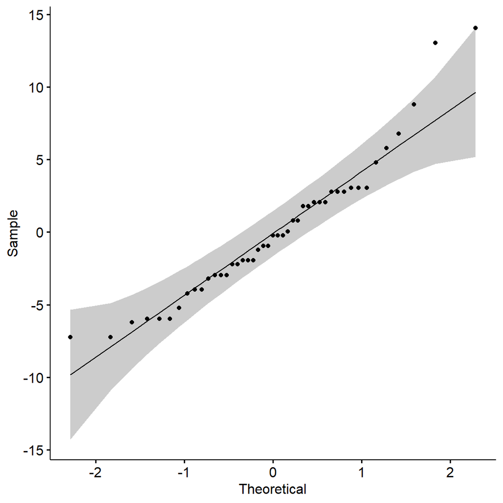

```r
ggqqplot(residuals(one_mod))
```

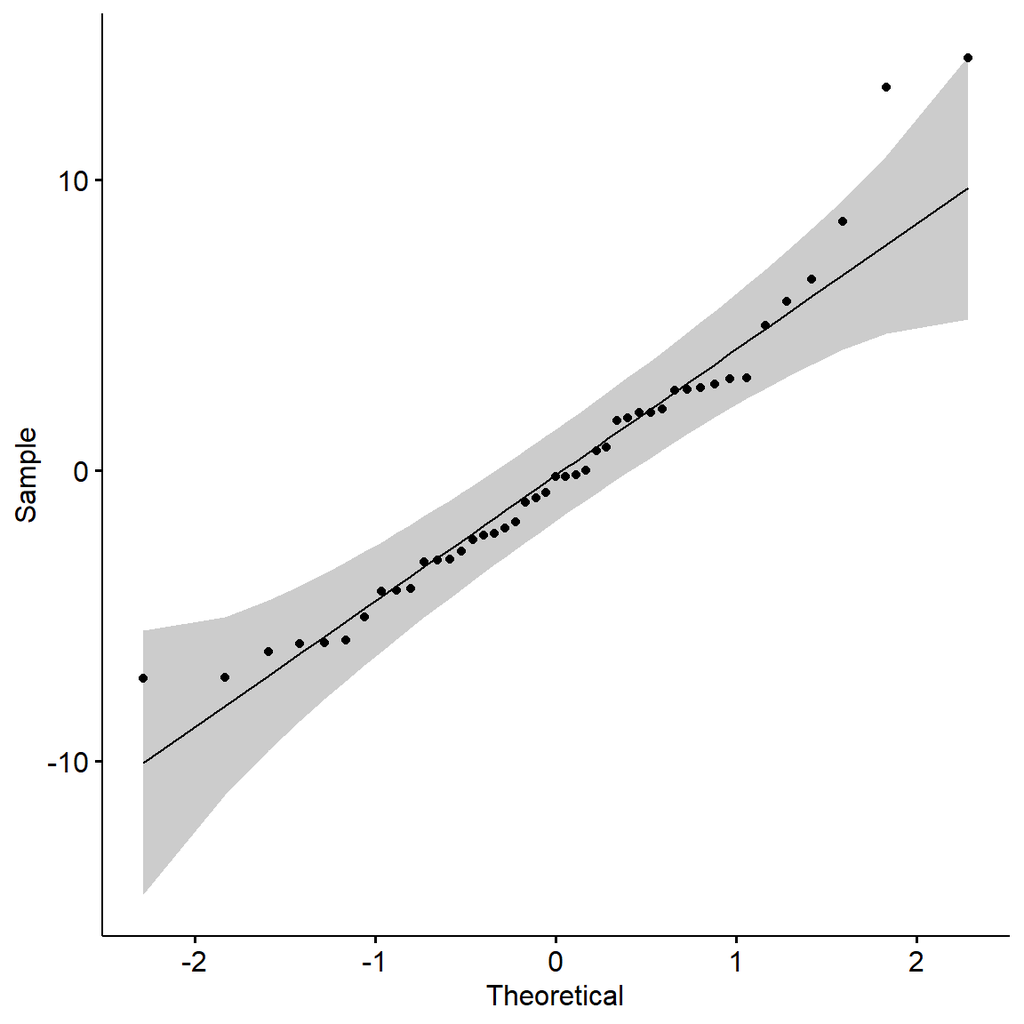

```r
ggqqplot(residuals(one_mod_anc))
```

Now I want to estimate 95% confidence interval for the difference between partner status.

```r
emmeans(one_mod_anc, "partner.status") %>%
    pairs %>%
    confint
```

```
 contrast   estimate   SE df lower.CL upper.CL
 high - low     4.27 1.46 42     1.33     7.21

Confidence level used: 0.95
```

- Report your results properly.

REPORT:

To check conformity level in the relation with the status of your partner, an experimental study was conducted on subjects who were paired with a partner of either low or high status. The dependent variable was conformity and independent variable was partner status. The subject’s authoritarianism was also measured with a F-scale score. One-way ANOVA has been conducted to study differences between the group with low and high status partner. It has yielded significant results indicating that the amount of conforming responses was different depending on the partner status. Fscore did not have any effect on the conformity level (p-value = 0.871940). Difference between estimated marginal means of high and low status was $4.27$ with $95$% confidence interval = $(1.33, 7.21)$ indicating that it is significant.

- Read the description of the dataset. What kind of study is it? Can you interpret your results in causal terms?

## 3.

Use `Adler` dataset from `carData` package. It is data from an experiment. Read its description (it is not super clear but what is important for us is to understand more or less what it is about and what is dependent variable and what are experimental factors).

```r
data("Adler")
Adler <- tibble(Adler)
Adler
```

```
# A tibble: 108 x 3
   instruction expectation rating
   <fct>       <fct>        <int>
 1 good        high            25
 2 good        high             0
 3 good        high           -16
 4 good        high             5
 5 good        high            11
 6 good        high            -6
 7 good        high            42
 8 good        high            -2
 9 good        high           -13
10 good        high            14
# ... with 98 more rows
```

- Do full analysis for all factors included in the experiment (allowing for possible interaction effects).

I have to check assumptions for Two-way Anova

```r
Adler %>%
  group_by(instruction, expectation) %>%
  get_summary_stats(rating, type = "mean_sd")
```

```
# A tibble: 6 x 6
  instruction expectation variable     n    mean    sd
  <fct>       <fct>       <chr>    <dbl>   <dbl> <dbl>
1 good        high        rating      18   4.44  15.4
2 good        low         rating      18 -18.3   10.3
3 none        high        rating      18  -9.83  14.7
4 none        low         rating      18  -3.5   11.6
5 scientific  high        rating      18  -6.94   8.45
6 scientific  low         rating      18   0.833 10.5
```

Group sizes are equal

```r
Adler %>%
  group_by(instruction, expectation) %>%
  identify_outliers(rating)
```

```
# A tibble: 4 x 5
  instruction expectation rating is.outlier is.extreme
  <fct>       <fct>        <int> <lgl>      <lgl>
1 good        high            42 TRUE       FALSE
2 good        low             -2 TRUE       FALSE
3 good        low             12 TRUE       TRUE
4 good        low             -8 TRUE       FALSE
```

There are four outliers, all in the ‘good’ group, so if I removed them, I wouldn’t have equal samples

Normality

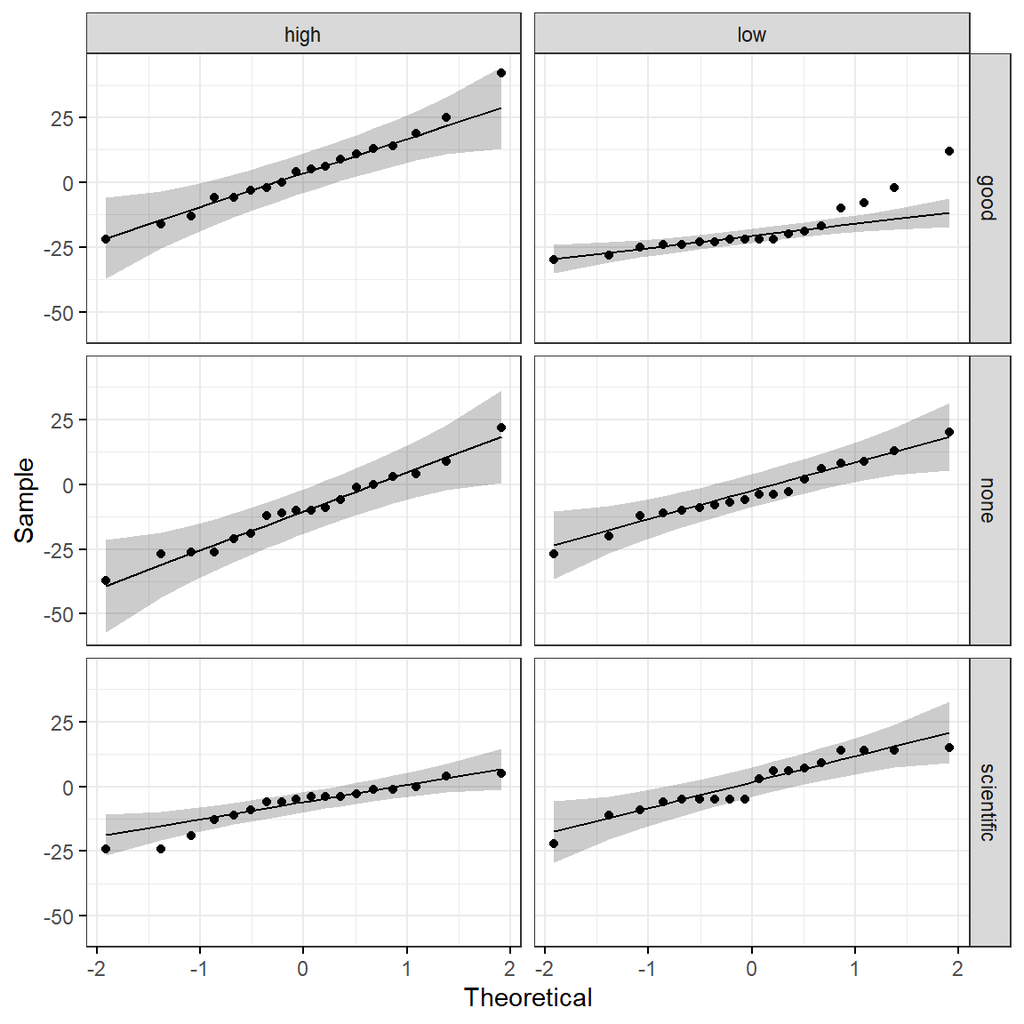

```r
ggqqplot(Adler, "rating", ggtheme = theme_bw()) +
  facet_grid(instruction ~ expectation)
```

There are no major disruptions and we can assess that the model is more or less normal.

Normality of model residuals:

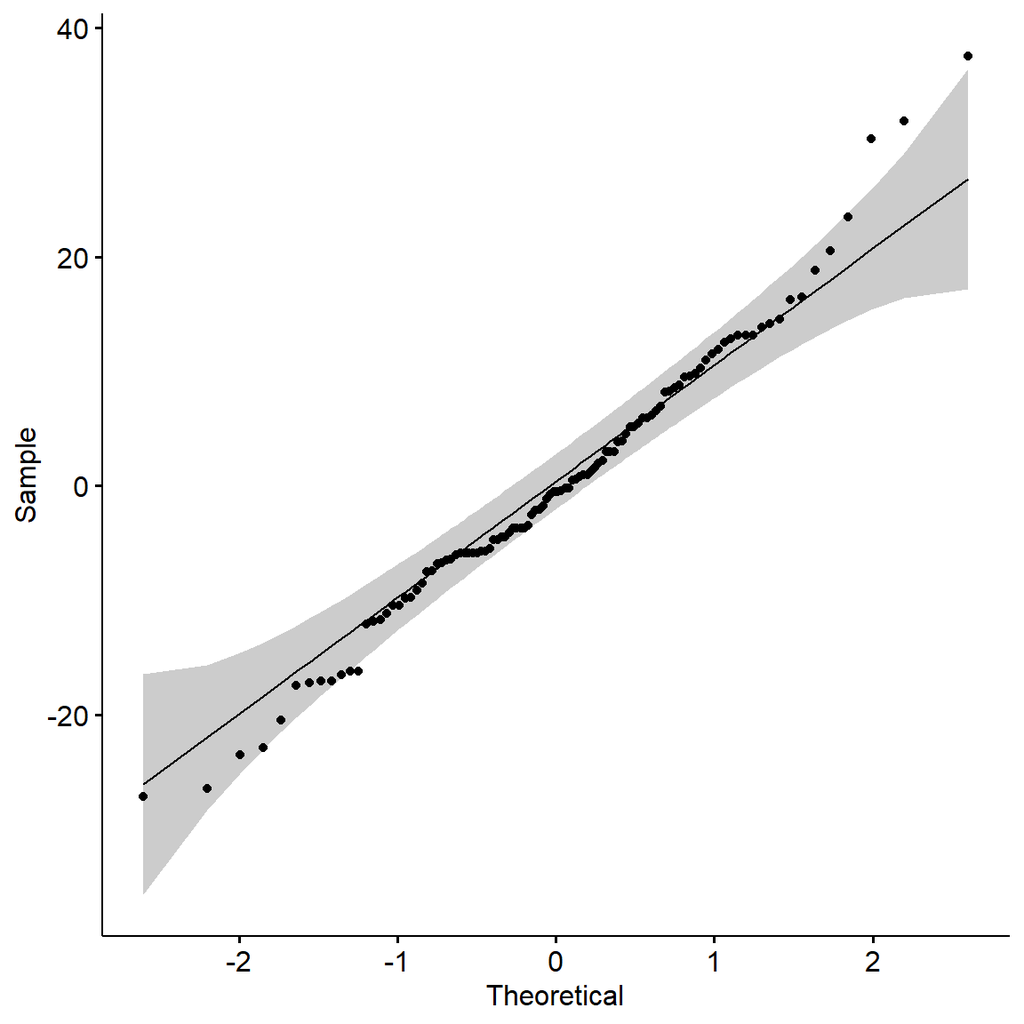

```r
res  <- lm(rating ~ expectation*instruction, data = Adler)

ggqqplot(residuals(res))
```

We can assume normality

Homogeneity of variance with Levine’s test:

```r
Adler %>% levene_test(rating ~ expectation*instruction)
```

```
# A tibble: 1 x 4
    df1   df2 statistic     p
  <int> <int>     <dbl> <dbl>
1     5   102      1.53 0.188
```

p > 0.05 indicates that the variances are homogenous

Linearity

```r
raintest(res)
```

```
    Rainbow test

data:  res
Rain = 1.1196, df1 = 54, df2 = 48, p-value = 0.3465
```

The model is linear.

Now we can safely conduct a Two-way Anova

```r
aov2 <- lm(rating ~ expectation*instruction, data = Adler)
summary(aov2)
```

```
Call:
lm(formula = rating ~ expectation * instruction, data = Adler)

Residuals:
    Min      1Q  Median      3Q     Max
-27.167  -6.458  -0.500   7.250  37.556

Coefficients:
                                     Estimate Std. Error t value
(Intercept)                             4.444      2.848   1.561
expectationlow                        -22.722      4.027  -5.642
instructionnone                       -14.278      4.027  -3.545
instructionscientific                 -11.389      4.027  -2.828
expectationlow:instructionnone         29.056      5.696   5.101
expectationlow:instructionscientific   30.500      5.696   5.355
                                     Pr(>|t|)
(Intercept)                          0.121709
expectationlow                       1.51e-07 ***
instructionnone                      0.000594 ***
instructionscientific                0.005643 **
expectationlow:instructionnone       1.56e-06 ***
expectationlow:instructionscientific 5.31e-07 ***
---
Signif. codes:  0 '***' 0.001 '**' 0.01 '*' 0.05 '.' 0.1 ' ' 1

Residual standard error: 12.08 on 102 degrees of freedom
Multiple R-squared:  0.2834,    Adjusted R-squared:  0.2483
F-statistic: 8.067 on 5 and 102 DF,  p-value: 1.919e-06
```

We can observe significant interaction effects.

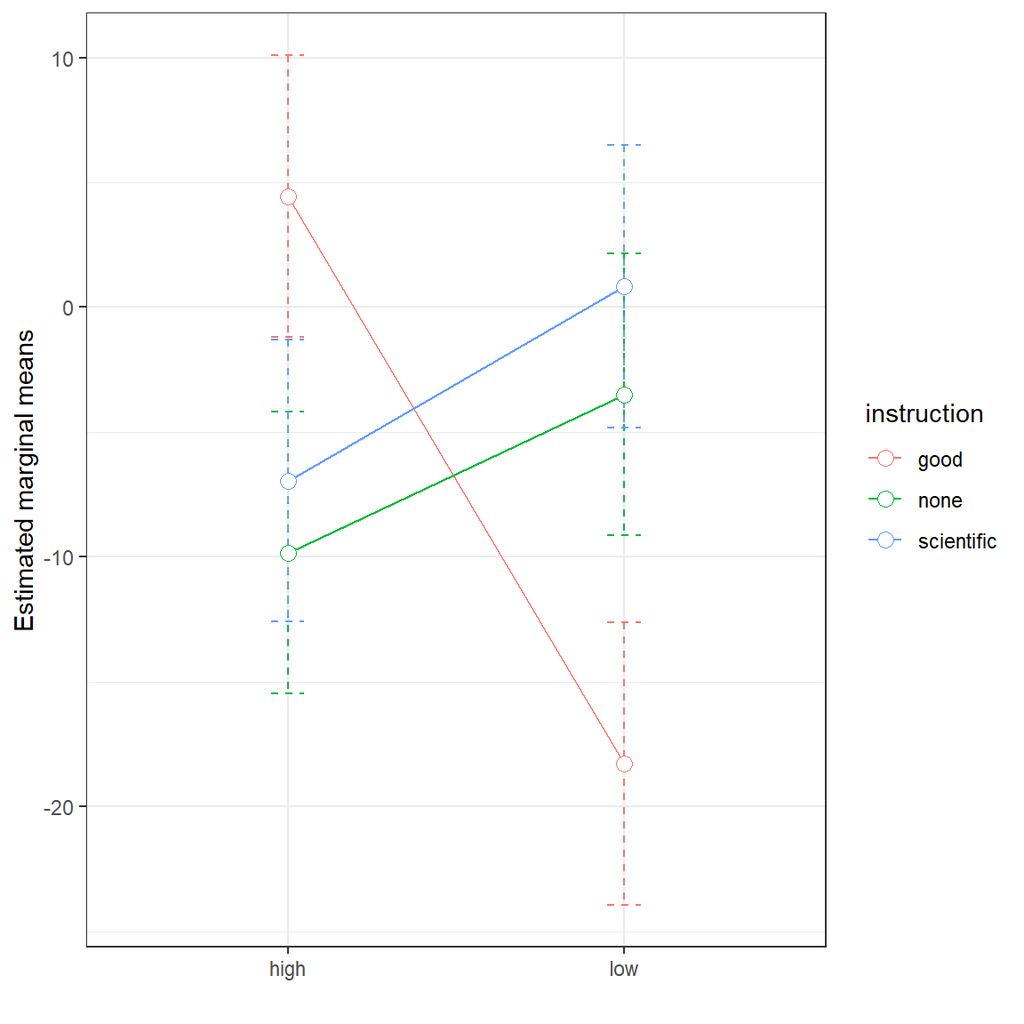

```r
aov2 %>%
    emmeans(c("expectation", "instruction")) %>%
    tidy(conf.int = TRUE) %>%
    ggplot(aes(x = expectation, y = estimate, group = instruction, color = instruction)) +
    geom_line() +
    geom_errorbar(aes(ymin = conf.low, ymax = conf.high), width = .1, linetype = 2) +
    geom_point(shape = 21, size = 3, fill = "white") +
    labs(x = "", y = "Estimated marginal means")
```

We can see that there are interaction effects between instruction (for good) and expectation. Therefore, we cannot study main effects and we have to focus of simple effects and interaction.

- Explain the interpretation of regression coefficients in you final model (remember that by default `R` uses treatment coding).

Using the coefficients we can calculate expected value (mean) of each condition:

$$\mathbb{E}[Y|high, good] = b_0 = 4.444
\\\mathbb{E}[Y|low, good] = b_0 + b_1 = 4.444 - 22.722 = -18.278
\\\mathbb{E}[Y|high, none] = b_0 + b_2 = 4.444 - 14.278 = -9.834
\\\mathbb{E}[Y|high, scientific] = b_0 + b_3 = 4.444 - 11.389 = -6.945
\\\mathbb{E}[Y|low, none] = b_0 + b_1 + b_2 + b_4 = 4.444 - 22.722 - 14.278 + 29.056 = -3.5
\\\mathbb{E}[Y|low, scientific] = b_0 + b_1 + b_3 + b_5 = 4.444 - 22.722 - 11.389 + 30.5 = 0.833$$
* Do *post hoc* analysis and report your results properly (remember about at least some basic effect size measures).

In the model we have significant interactions, so we should perform post-hoc tests to truly understand our model, but ignore main effect and focus on interactions.

```r
etasq(aov2, anova = TRUE, partial = TRUE)
```

```
Anova Table (Type II tests)

Response: rating
                        Partial eta^2  Sum Sq  Df F value    Pr(>F)
expectation                  0.014719   222.5   1  1.5238    0.2199
instruction                  0.022075   336.1   2  1.1512    0.3203
expectation:instruction      0.263582  5329.7   2 18.2542 1.672e-07
Residuals                             14890.5 102

expectation
instruction
expectation:instruction ***
Residuals
---
Signif. codes:  0 '***' 0.001 '**' 0.01 '*' 0.05 '.' 0.1 ' ' 1
```

Expectation instruction is in fact, significant. We cannot conclude anything about main effect with interaction effect present.

Two one-way ANOVAs for expectation and instruction

```r
simple <- emmeans(aov2, ~expectation|instruction)
test(pairs(simple), joint = TRUE)
```

```
 instruction df1 df2 F.ratio p.value
 good          1 102  31.830 <.0001
 none          1 102   2.473 0.1189
 scientific    1 102   3.729 0.0562
```

```r
simple2 <- emmeans(aov2, ~instruction|expectation)
test(pairs(simple2), joint = TRUE)
```

```
 expectation df1 df2 F.ratio p.value note
 high          2 102   7.026 0.0014   d
 low           2 102  12.379 <.0001   d

d: df1 reduced due to linear dependence
```

We can see significant results, but I can conduct more detailed tests:

Estimating simple effects:

```r
noise.emm <- emmeans(aov2, ~ instruction * expectation)
contrast(noise.emm, "consec", simple = "each", combine = TRUE, adjust = "mvt")
```

```
 expectation instruction contrast          estimate   SE  df t.ratio
 high        .           none - good         -14.28 4.03 102 -3.545
 high        .           scientific - none     2.89 4.03 102  0.717
 low         .           none - good          14.78 4.03 102  3.669
 low         .           scientific - none     4.33 4.03 102  1.076
 .           good        low - high          -22.72 4.03 102 -5.642
 .           none        low - high            6.33 4.03 102  1.573
 .           scientific  low - high            7.78 4.03 102  1.931
 p.value
 0.0039
 0.9592
 0.0027
 0.8162
 <.0001
 0.4894
 0.2747

P value adjustment: mvt method for 7 tests
```

```r
contrast(noise.emm, "pairwise", by="expectation")
```

```
expectation = high:
 contrast          estimate   SE  df t.ratio p.value
 good - none          14.28 4.03 102  3.545  0.0017
 good - scientific    11.39 4.03 102  2.828  0.0154
 none - scientific    -2.89 4.03 102 -0.717  0.7538

expectation = low:
 contrast          estimate   SE  df t.ratio p.value
 good - none         -14.78 4.03 102 -3.669  0.0011
 good - scientific   -19.11 4.03 102 -4.745  <.0001
 none - scientific    -4.33 4.03 102 -1.076  0.5311

P value adjustment: tukey method for comparing a family of 3 estimates
```

```r
contrast(noise.emm, "pairwise", by="instruction")
```

```
instruction = good:
 contrast   estimate   SE  df t.ratio p.value
 high - low    22.72 4.03 102  5.642  <.0001

instruction = none:
 contrast   estimate   SE  df t.ratio p.value
 high - low    -6.33 4.03 102 -1.573  0.1189

instruction = scientific:
 contrast   estimate   SE  df t.ratio p.value
 high - low    -7.78 4.03 102 -1.931  0.0562
```

Report:

In order to study differences in rating of success under conditions of low or high expectancy with receiving good, scientific or no instruction, a two-way ANOVA has been conducted. The first condition was expectation (either low or high) and the second experimental condition was of scientific, good or none instruction. An interaction term was also included in the analysis. The dependent variable was the rating provided by the subject.

Analysis of variance showed that the interaction effect was significant and was associated with about 26% of the variance of the dependent variable (calculated with partial $\eta^2$). A post-hoc test for simple effects revealed following significant results (p-value adjusted with tukey method for 3 estimates):

simple effect of instruction for expectation = low or expectation = high:

- expectation = high: instruction (good - none) (p-value = 0.0017),
- expectation = high: instruction (good - scientific) (p-value = 0.0154),
- expectation = low: instruction (good - none) (p-value = 0.0011),
- expectation = low: instruction (good - scientific) (p-value <.0001),

and simple effect of expectation when instruction = good:

- instruction = good: expectation (high - low) (p-value <.0001).

## 4.

Use `GSSvocab` dataset from `carData` package. Read its description and determine what kind of study it is (i.e. is it an experiment or a correlational study). Use a linear model to study correlates/determinants of linguistic skills (`vocab` variable).

- Use only data for year 2016.
- Remember about avoiding unnecessary discretization of continuous predictors.
- Apart from that use as many variables as possible (in a rather exploratory fashion).
- Interpret and report your results.

**NOTE.** This problem can be solved in particarily many equally good ways. Do not worry about this. Anything that is clear and sound will be accepted.

```r
data("GSSvocab")
GSSvocab <- tibble(GSSvocab)
GSSvocab <- GSSvocab %>% filter(year == 2016)
GSSvocab
```

```
# A tibble: 1,888 x 8
   year  gender nativeBorn ageGroup educGroup vocab   age  educ
   <fct> <fct>  <fct>      <fct>    <fct>     <dbl> <dbl> <dbl>
 1 2016  male   yes        40-49    16 yrs        8    47    16
 2 2016  male   yes        60+      12 yrs        5    61    12
 3 2016  female yes        40-49    12 yrs        5    43    12
 4 2016  female no         50-59    13-15 yrs     8    53    14
 5 2016  male   no         50-59    13-15 yrs     6    50    14
 6 2016  male   no         40-49    12 yrs        6    45    12
 7 2016  female yes        30-39    12 yrs        3    33    12
 8 2016  female yes        60+      12 yrs        3    86    12
 9 2016  male   yes        30-39    12 yrs        4    32    12
10 2016  male   yes        60+      <12 yrs       4    76    10
# ... with 1,878 more rows
```

```r
GSSvocab <- GSSvocab[complete.cases(GSSvocab),]
```

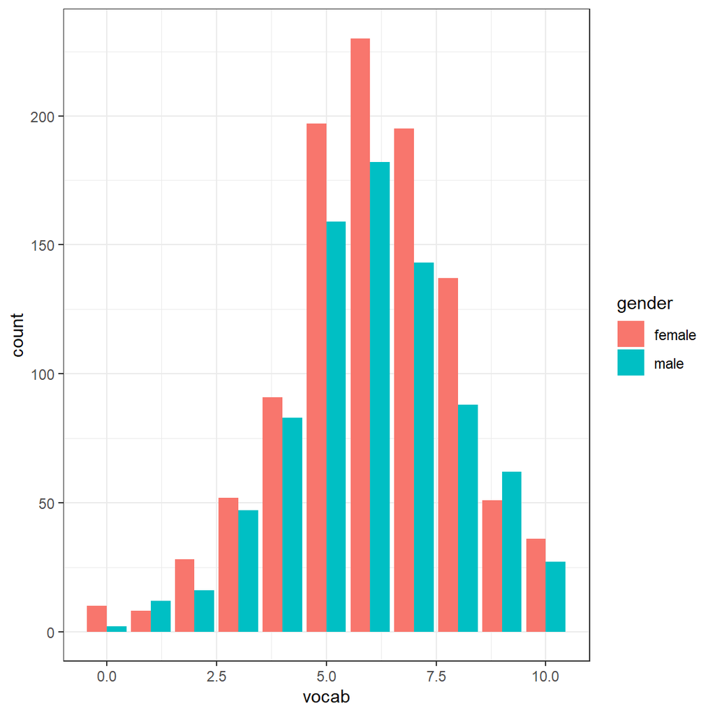

```r
GSSvocab %>%
    ggplot(aes(x = vocab, fill = gender)) +
    geom_bar(stat = "count", position = "dodge")
```

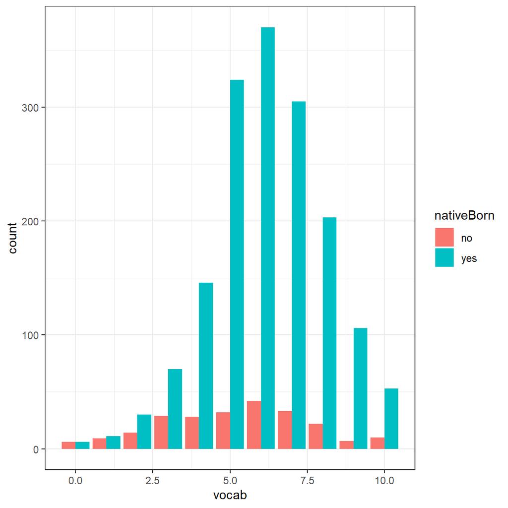

```r
GSSvocab %>%
    ggplot(aes(x = vocab, fill = nativeBorn)) +
    geom_bar(stat = "count", position = "dodge")
```

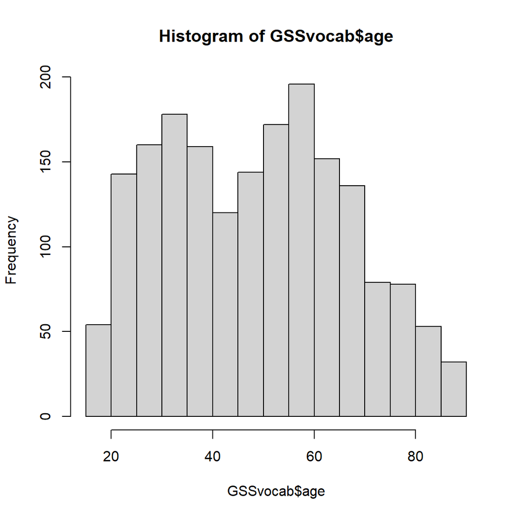

```r
hist(GSSvocab$age)
```

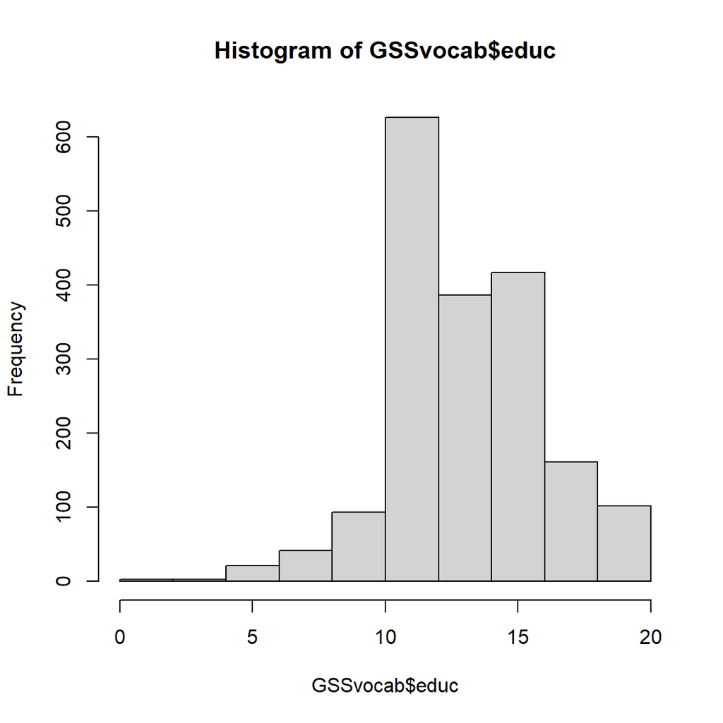

```r
hist(GSSvocab$educ)
```

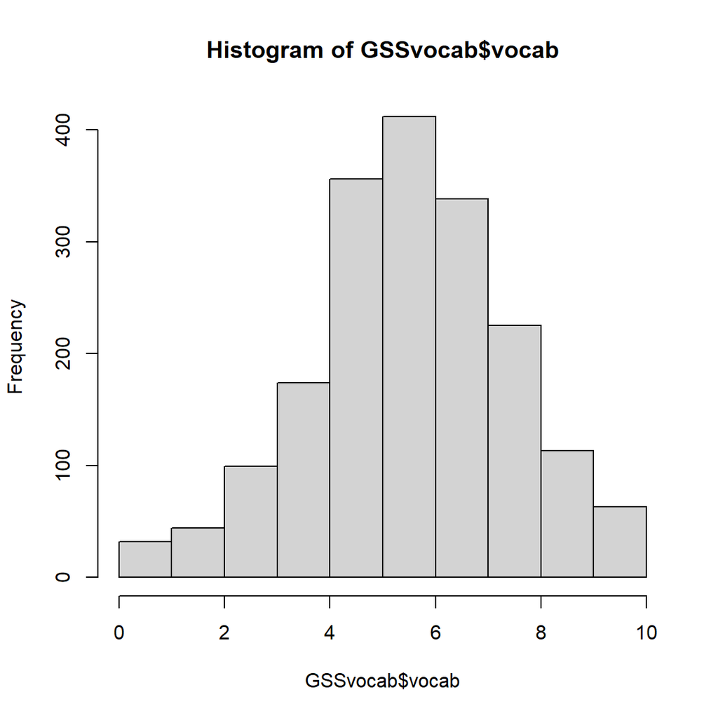

```r
hist(GSSvocab$vocab)
```

```r
GSSvocab[, c(2,3,6,7,8)]
```

```
# A tibble: 1,856 x 5
   gender nativeBorn vocab   age  educ
   <fct>  <fct>      <dbl> <dbl> <dbl>
 1 male   yes            8    47    16
 2 male   yes            5    61    12
 3 female yes            5    43    12
 4 female no             8    53    14
 5 male   no             6    50    14
 6 male   no             6    45    12
 7 female yes            3    33    12
 8 female yes            3    86    12
 9 male   yes            4    32    12
10 male   yes            4    76    10
# ... with 1,846 more rows
```

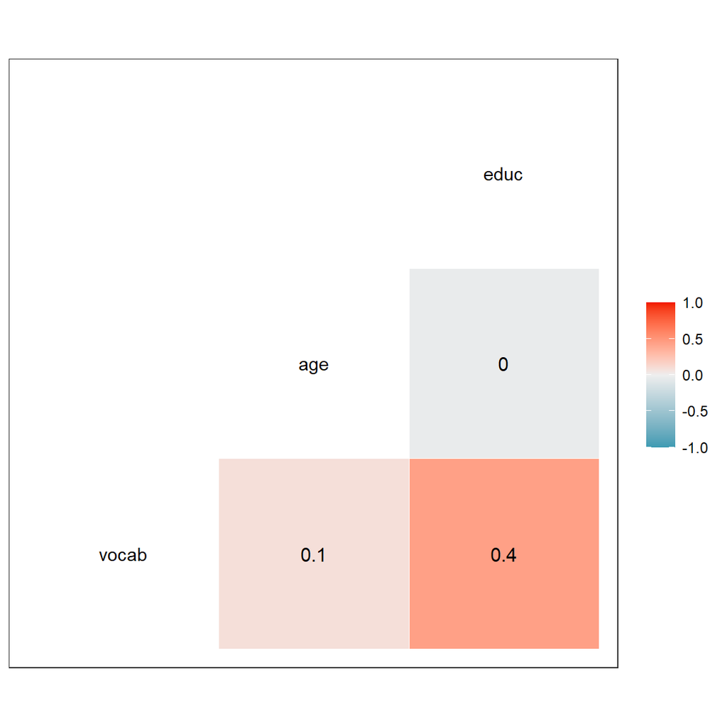

```r
ggcorr(GSSvocab[, c(2,3,6,7,8)], label = TRUE)
```

This is the first model I create to see more or less which factors are important and if there is any interaction

```r
test <- lm(vocab ~ nativeBorn * (age + educ + gender), data = GSSvocab)
summary(test)
```

```
Call:
lm(formula = vocab ~ nativeBorn * (age + educ + gender), data = GSSvocab)

Residuals:
    Min      1Q  Median      3Q     Max
-7.2604 -1.0007  0.0364  1.1702  6.0962

Coefficients:
                          Estimate Std. Error t value Pr(>|t|)
(Intercept)               1.505841   0.498388   3.021  0.00255 **
nativeBornyes            -0.116363   0.561356  -0.207  0.83581
age                       0.007376   0.006544   1.127  0.25984
educ                      0.256010   0.028125   9.103  < 2e-16 ***
gendermale                0.028630   0.226937   0.126  0.89962
nativeBornyes:age         0.003366   0.006947   0.484  0.62810
nativeBornyes:educ        0.049569   0.032283   1.535  0.12484
nativeBornyes:gendermale -0.046025   0.242256  -0.190  0.84934
---
Signif. codes:  0 '***' 0.001 '**' 0.01 '*' 0.05 '.' 0.1 ' ' 1

Residual standard error: 1.698 on 1848 degrees of freedom
Multiple R-squared:  0.2212,    Adjusted R-squared:  0.2182
F-statistic: 74.97 on 7 and 1848 DF,  p-value: < 2.2e-16
```

There are no interactions, we can try another model

```r
lang <- lm(vocab ~ nativeBorn + age + educ + gender, data = GSSvocab)
summary(lang)
```

```
Call:
lm(formula = vocab ~ nativeBorn + age + educ + gender, data = GSSvocab)

Residuals:
    Min      1Q  Median      3Q     Max
-7.6460 -0.9897  0.0491  1.1797  6.0079

Coefficients:
               Estimate Std. Error t value Pr(>|t|)
(Intercept)    0.889574   0.242603   3.667 0.000253 ***
nativeBornyes  0.686321   0.119580   5.739 1.11e-08 ***
age            0.010293   0.002196   4.688 2.96e-06 ***
educ           0.293562   0.013801  21.271  < 2e-16 ***
gendermale    -0.014168   0.079391  -0.178 0.858384
---
Signif. codes:  0 '***' 0.001 '**' 0.01 '*' 0.05 '.' 0.1 ' ' 1

Residual standard error: 1.698 on 1851 degrees of freedom
Multiple R-squared:  0.2201,    Adjusted R-squared:  0.2184
F-statistic: 130.6 on 4 and 1851 DF,  p-value: < 2.2e-16
```

We can remove gender, but just to be sure I will try different models and see which one is the best

```r
model1 = lm(vocab ~ educ,
           data = GSSvocab)

model2 = lm(vocab ~ educ + age,
           data = GSSvocab)

model3 = lm(vocab ~ educ + age + nativeBorn,
           data = GSSvocab)

model4 = lm(vocab ~ age + nativeBorn,
           data = GSSvocab)

model5 = lm(vocab ~ nativeBorn,
           data = GSSvocab)

model6 = lm(vocab ~ age,
           data = GSSvocab)

model7 = lm(vocab ~ educ + nativeBorn,
           data = GSSvocab)


compareLM(model1, model2, model3, model4, model5, model6, model7)
```

```
$Models
  Formula
1 "vocab ~ educ"
2 "vocab ~ educ + age"
3 "vocab ~ educ + age + nativeBorn"
4 "vocab ~ age + nativeBorn"
5 "vocab ~ nativeBorn"
6 "vocab ~ age"
7 "vocab ~ educ + nativeBorn"

$Fit.criteria
  Rank Df.res  AIC AICc  BIC R.squared Adj.R.sq   p.value Shapiro.W
1    2   1854 7290 7290 7306  0.195800  0.19540 7.390e-90    0.9920
2    3   1853 7268 7268 7290  0.206200  0.20530 1.231e-93    0.9930
3    4   1852 7237 7237 7265  0.220100  0.21880 1.825e-99    0.9954
4    3   1853 7641 7641 7663  0.029410  0.02837 9.714e-13    0.9908
5    2   1854 7652 7652 7668  0.022750  0.02222 6.536e-11    0.9760
6    2   1854 7680 7680 7697  0.007735  0.00720 1.484e-04    0.9874
7    3   1853 7257 7257 7279  0.210800  0.20990 5.717e-96    0.9945
  Shapiro.p
1 1.458e-08
2 1.115e-07
3 1.660e-05
4 2.057e-09
5 4.326e-17
6 1.179e-11
7 2.067e-06
```

Based on $R^2$, model 3 is the best

```r
lang2 <- lm(vocab ~ nativeBorn + educ + age, data = GSSvocab)
summary(lang2)
```

```
Call:
lm(formula = vocab ~ nativeBorn + educ + age, data = GSSvocab)

Residuals:
    Min      1Q  Median      3Q     Max
-7.6405 -0.9920  0.0484  1.1793  5.9999

Coefficients:
              Estimate Std. Error t value Pr(>|t|)
(Intercept)   0.883424   0.240079   3.680  0.00024 ***
nativeBornyes 0.685772   0.119509   5.738 1.12e-08 ***
educ          0.293560   0.013798  21.276  < 2e-16 ***
age           0.010301   0.002195   4.694 2.88e-06 ***
---
Signif. codes:  0 '***' 0.001 '**' 0.01 '*' 0.05 '.' 0.1 ' ' 1

Residual standard error: 1.697 on 1852 degrees of freedom
Multiple R-squared:  0.2201,    Adjusted R-squared:  0.2188
F-statistic: 174.2 on 3 and 1852 DF,  p-value: < 2.2e-16
```

```r
etasq(lang2, anova = TRUE, type = 2)
```

```
Anova Table (Type II tests)

Response: vocab
           Partial eta^2 Sum Sq   Df F value    Pr(>F)
nativeBorn      0.017469   94.9    1  32.927 1.115e-08 ***
educ            0.196415 1304.3    1 452.673 < 2.2e-16 ***
age             0.011755   63.5    1  22.030 2.882e-06 ***
Residuals                5336.0 1852
---
Signif. codes:  0 '***' 0.001 '**' 0.01 '*' 0.05 '.' 0.1 ' ' 1
```

Effects of all included variables are significant

Now we can check assumptions for linear model.

Normality of residuals:

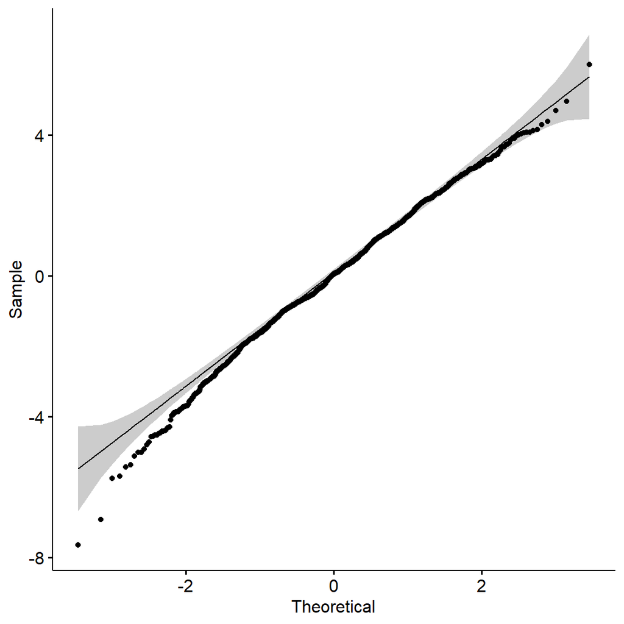

```r
ggqqplot(residuals(lang2))
```

This is acceptable

Homogeneity of residuals:

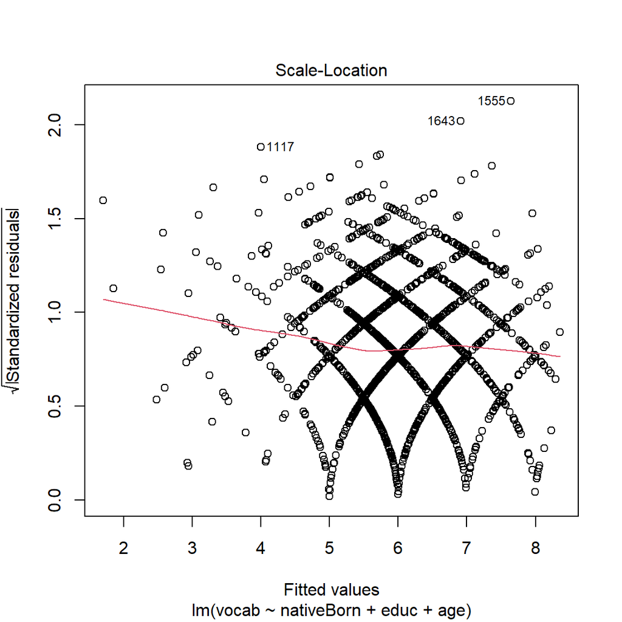

```r
plot(lang2, 3)
```

It is not perfect, but stable. We can move on

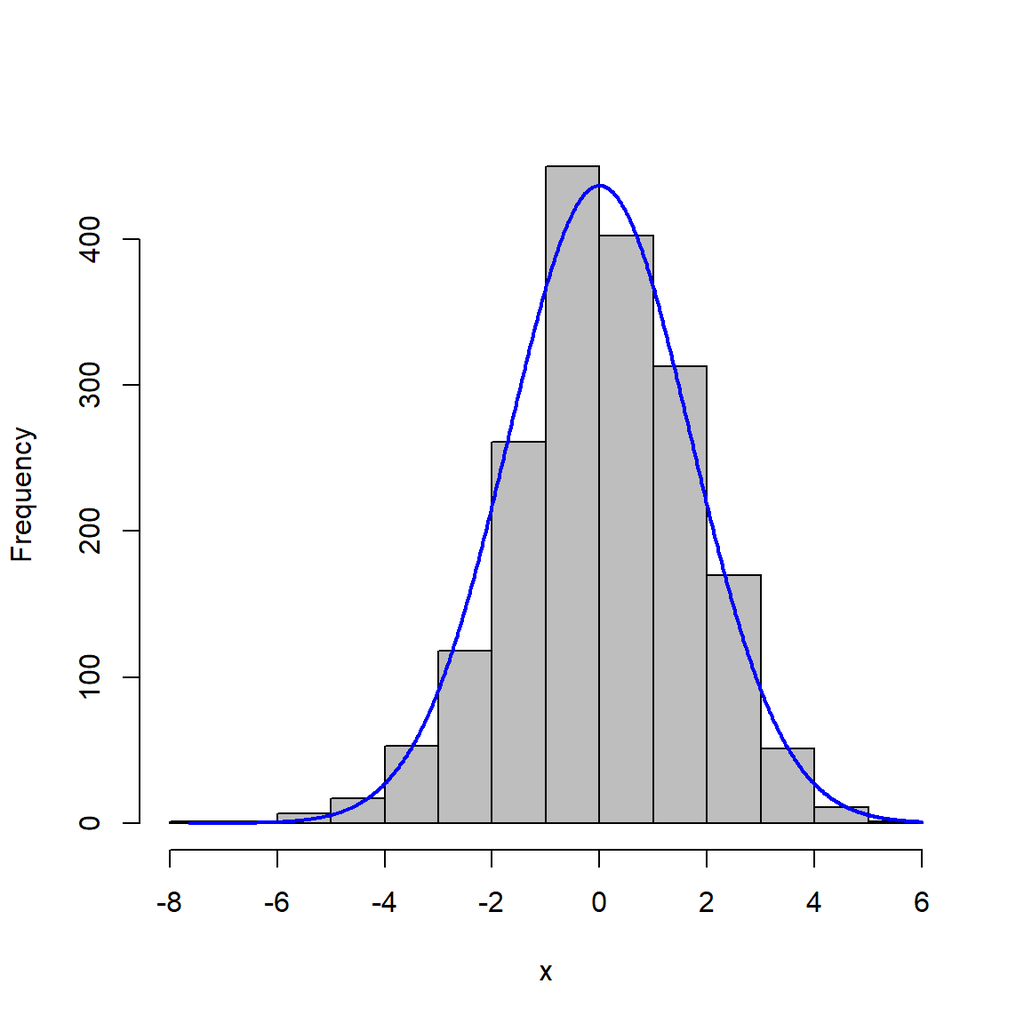

```r
plotNormalHistogram(residuals(lang2))
```

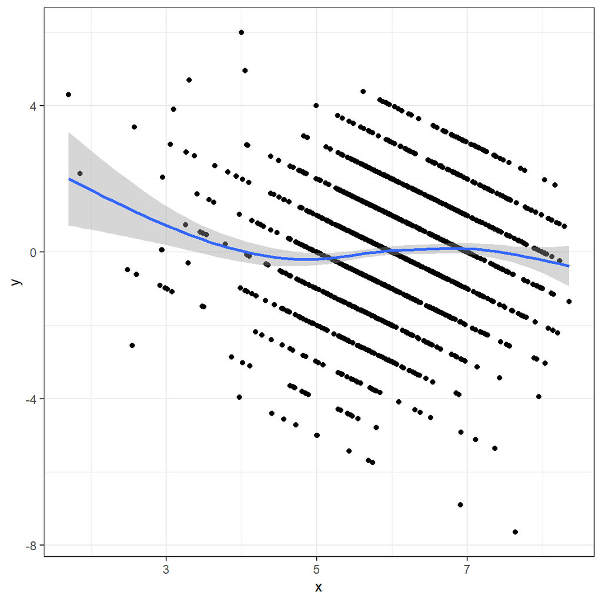

```r
tibble(
    x = fitted(lang2),
    y = resid(lang2)
) %>%
    ggplot(aes(x = x, y = y)) +
    geom_point() +
    geom_smooth(method = "gam")
```

Model can be assumed linear

Next I will study model accuracy

```r
print(paste0("Adjusted R^2: ", summary(lang2)$adj.r.squared))
```

```
[1] "Adjusted R^2: 0.218787891384145"
```

```r
print(paste0("RSE: ", sigma(lang2)))
```

```
[1] "RSE: 1.69741748135105"
```

```r
print(paste0("Error rate: ", sigma(lang2)/mean(GSSvocab$vocab)))
```

```
[1] "Error rate: 0.282142830502199"
```

We have 3 predictors, so I look at adjusted $R^2$. About 21% of the variance is explained by the predictors. $RSE = 1.697$ and we can calculate error rate which is 28%. This is not a very good model

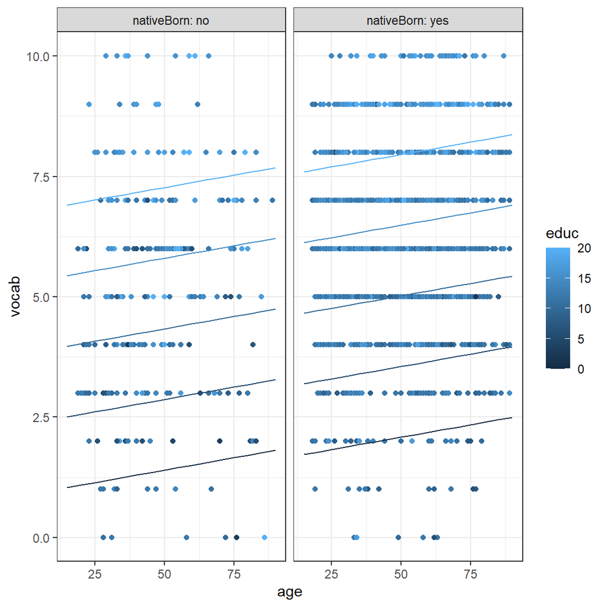

```r
ggPredict(lm(vocab ~ age + educ + nativeBorn, data = GSSvocab))
```

```r
summary(lang2)
```

```
Call:
lm(formula = vocab ~ nativeBorn + educ + age, data = GSSvocab)

Residuals:
    Min      1Q  Median      3Q     Max
-7.6405 -0.9920  0.0484  1.1793  5.9999

Coefficients:
              Estimate Std. Error t value Pr(>|t|)
(Intercept)   0.883424   0.240079   3.680  0.00024 ***
nativeBornyes 0.685772   0.119509   5.738 1.12e-08 ***
educ          0.293560   0.013798  21.276  < 2e-16 ***
age           0.010301   0.002195   4.694 2.88e-06 ***
---
Signif. codes:  0 '***' 0.001 '**' 0.01 '*' 0.05 '.' 0.1 ' ' 1

Residual standard error: 1.697 on 1852 degrees of freedom
Multiple R-squared:  0.2201,    Adjusted R-squared:  0.2188
F-statistic: 174.2 on 3 and 1852 DF,  p-value: < 2.2e-16
```

Report:

In order to study differences in vocabulary test for subjects born in the USA and foreigners a correlation research was conducted. Variables that were also controlled were age, gender and years of education. An interaction term was also included in the analysis. The dependent variable was the score in vocabulary test.

In order to test the nature of the variables, linear model was designed to study correlates of linguistic skills. Two-way ANOVA revealed no significant interactions and significant effect of nativeBorn, age and educ (p-value < 0.05) and about 21% of the variance is explained by the predictors. Using coefficients established via ANCOVA, multiple regression equation is the following: $y = 0.883424 + 0.685772*x_1 + 0.29356*x_2 + 0.010301*x_3$

($x_1$ - nativeBorn, $x_2$ - educ, $x_3$ - age)

## 5.

Use data from exercise 4 (`GSSvocab`). Consider `vocab` as the dependent variable and two predictors: `age` and `educ`. Estimate total effect of `age` on `vocab`, direct effect of `age` on vocab and indirect effect of `age` on vocab mediated by (transferred through) `educ`.

You do not have to run tests or calculate confidence intervals. Just estimate appropriate regression coefficients. However, if you want you may try to calculate confidence intervals for different effects (it is easy to do this for total and direct effect but indirect effect may require bootstraping).

**HINT.** If you are not sure what this proble is about go back to chapter 11 in the textbook and section 11.6 in particular.

ANSWER:

mediator - educ

predictor - age

dependent variable - vocab

Total effect of `age` on `vocab`:

```r
totaleffect = lm(vocab~age,GSSvocab)
summary(totaleffect)
```

```
Call:
lm(formula = vocab ~ age, data = GSSvocab)

Residuals:
    Min      1Q  Median      3Q     Max
-6.3632 -1.0814  0.0125  1.1534  4.2097

Coefficients:
            Estimate Std. Error t value Pr(>|t|)
(Intercept) 5.555506   0.129059  43.046  < 2e-16 ***
age         0.009392   0.002470   3.802 0.000148 ***
---
Signif. codes:  0 '***' 0.001 '**' 0.01 '*' 0.05 '.' 0.1 ' ' 1

Residual standard error: 1.914 on 1854 degrees of freedom
Multiple R-squared:  0.007735,  Adjusted R-squared:  0.0072
F-statistic: 14.45 on 1 and 1854 DF,  p-value: 0.0001484
```

Total effect = 0.009392 and it is significant (p-value < 0.5)

Direct effect of `age` on vocab:

```r
direct = lm(vocab~age + educ, GSSvocab)
summary(direct)
```

```
Call:
lm(formula = vocab ~ age + educ, data = GSSvocab)

Residuals:
   Min     1Q Median     3Q    Max
-8.294 -1.029  0.050  1.205  6.117

Coefficients:
            Estimate Std. Error t value Pr(>|t|)
(Intercept) 1.383472   0.225625   6.132 1.06e-09 ***
age         0.010861   0.002211   4.912 9.82e-07 ***
educ        0.298846   0.013885  21.523  < 2e-16 ***
---
Signif. codes:  0 '***' 0.001 '**' 0.01 '*' 0.05 '.' 0.1 ' ' 1

Residual standard error: 1.712 on 1853 degrees of freedom
Multiple R-squared:  0.2062,    Adjusted R-squared:  0.2053
F-statistic: 240.6 on 2 and 1853 DF,  p-value: < 2.2e-16
```

The effect of the age onto educ:

```r
mediator = lm(educ~age,GSSvocab)
summary(mediator)
```

```
Call:
lm(formula = educ ~ age, data = GSSvocab)

Residuals:
     Min       1Q   Median       3Q      Max
-12.7097  -1.7404  -0.6261   2.2313   6.4772

Coefficients:
             Estimate Std. Error t value Pr(>|t|)
(Intercept) 13.960485   0.193131   72.28   <2e-16 ***
age         -0.004917   0.003697   -1.33    0.184
---
Signif. codes:  0 '***' 0.001 '**' 0.01 '*' 0.05 '.' 0.1 ' ' 1

Residual standard error: 2.864 on 1854 degrees of freedom
Multiple R-squared:  0.0009534, Adjusted R-squared:  0.0004145
F-statistic: 1.769 on 1 and 1854 DF,  p-value: 0.1836
```

Direct effect of `age` on vocab = 0.010861.

```r
results <- mediate(mediator, direct, treat='age', mediator='educ', boot=T)
summary(results)
```

```
Causal Mediation Analysis

Nonparametric Bootstrap Confidence Intervals with the Percentile Method

               Estimate 95% CI Lower 95% CI Upper p-value
ACME           -0.00147     -0.00361         0.00    0.17
ADE             0.01086      0.00650         0.02  <2e-16 ***
Total Effect    0.00939      0.00434         0.01  <2e-16 ***
Prop. Mediated -0.15647     -0.58978         0.05    0.17
---
Signif. codes:  0 '***' 0.001 '**' 0.01 '*' 0.05 '.' 0.1 ' ' 1

Sample Size Used: 1856


Simulations: 1000
```

From ACME we can conclude indirect effect of `age` on vocab mediated by `educ`: -0.00147 ADE is direct effect of the age on vocab and it is 0.01086 and total effect is 0.00939, like we already calculated.